# Introduction to Python

# None type

There is something called `None`

```python
None
```

It's like a null pointer.

# Python Control Structures

```python
MIN_GRADE = 0.5
student = "Rita"
grade = 0.7

if grade > MIN_GRADE:
    print("{} passed".format(student))
    print("Congratulations")
else:
    print("{} needs to take the test again".format(student))
```

```
Rita passed
Congratulations
```

# Blocks are defined by indentation

Unlike almost all other modern programming languages, Python uses **indentation** to delimit blocks!

(This is sometimes called the [off-side rule](https://en.wikipedia.org/wiki/Off-side_rule)).

- you can use any number of spaces, but you should use **4 spaces**.
- you can use TABs, but please don't

```
if <condition>:
    <statement 1>
    <statement 2>
    <statement 3>
<statement after the if>
```

# Conditions

- `a == b`
- `a != b`
- `a < b`
- `a > b`
- `a >= b`
- `a in lst`
- `a not in lst`

# Else clause and friends

```python
a = 2
if a > 3:
    print("Greater than 3")
elif a > 2:
    print("Greater than 2")
elif a > 1:
    print("Greater than 1")
else:
    print("Kind of small")
```

```
Greater than 1
```

# Loops

## for loop

In Python, the `for` loop is over a "sequence":

```
for <name> in <sequence>:
    <block>
```

```python
students = ['Luis', "Ece", "Rita"]

for st in students:
    print(st)
```

```
Luis
Ece
Rita
```

We can also loop over dictionaries:

```python
for n in items:
    print(n)
```

```
laptop
phone
pen
movies
```

# while loop

By now, you can probably guess the syntax:

```
while <condition>:
    <block>
```

```python
# poor man's division
a = 2325250
b = 23

c = a
i = 0
while c > b:
    c -= b
    i += 1

print("{} // {} = {}".format(a, b, i))
```

```
2325250 // 23 = 101097
```

# More loopy stuff

In many other languages, for loops are over integers (0, 1, 2, ... , N). How can we achieve the same in Python?

```python
range(5)
```

```
range(0, 5)
```

```python
for i in range(5):
    print(i**2)
```

```
0
1
4
9
16
```

There was also `xrange` in Python 3 which is almost like `range`

# Conditions

We have seen comparisons already (e.g., `a < b`), they return booleans (either `True` or `False`):

```python
a = 1
b = 2
print(a < b)
print(a == b)
```

```
True
False
```

We can also use booleans as values:

```python
condition = True
if condition:
    print("Yep")
```

```
Yep
```

# Other Conditions

- Many things can be evaluated as conditions
  - lists (the empty list gets evaluated as `False`, otherwise `True`)
  - dicts (same)
  - strings (empty string evaluates to `False`, otherwise `True`)
  - numbers (zero is `False`, else `True`)
- Several other objects can be evaluated in conditions

```python
if fruits:
    print("Fruity")
else:
    print("Nope")
```

```
Fruity
```

# Break and continue

Like in other languages, in a loop `break` exits the loop and `continue` goes to the next iteration immediately:

```python
numbers = [1, 6, -13, -4, 2]

total = 0
n = 0.0

for v in numbers:
    if v < 0:
        continue
    total += v
    n += 1
total/n
```

```
3.0
```

# Functions

```python
def double(x):
    '''
    Returns the double of its argument
    '''
    return 2 * x

double(3)
```

[output not shown]

Is that a comment?

It's a documentation string.

Try `double?`

# Calling a function

```python
a = 4
double(a)
```

```
8
```

```python
double(2.3)
```

```
4.6
```

```python
double(double(a))
```

```
16
```

# Functions with default arguments

```python
def greet(name, greeting="Hello"):
    print("{} {}".format(greeting, name))

greet("Mario")
greet("Mario", "Goodbye")
```

```
Hello Mario
Goodbye Mario
```

You can also specify the argument names (and then the order does not matter):

```python
greet(greeting="Howdy", name="Mario")
```

```
Howdy Mario
```

This is very helpful for functions with >10 arguments!

# Breakpoint

Questions up to this point?

# NUMPY

Unlike R/MATLAB, Python relies on libraries for numerics.

- No builtin types for numeric computation
- However, packages like `numpy` are *quasi-standard*

## Basic array array type

`numpy.array`, which is a multi-dimensional array of numbers.

```python
import numpy as np # <- import a library, like include/require in other languages

A = np.array([
    [0,1,2],
    [2,3,4],
    [4,5,6],
    [6,7,8]])
print(A[0,0])
print(A[0,1])
print(A[1,0])
```

```
0
1
2
```

# Why do we need numpy?

Couldn't we just use lists?

```python
A = np.array([1,2,3])
B = [1, 2, 3]
```

1. numpy arrays have extra numeric methods.
2. efficiency
3. expressiveness

```python
A
```

```
array([1, 2, 3])
```

```python
A.mean()
```

```
2.0
```

```python
A.std()
```

```
0.816496580927726
```

```python
A.max()
```

```
3
```

You can also use numeric operations with arrays, they work **element-wise**:

```python
A
```

```
array([1, 2, 3])
```

```python
A + 1
```

```
array([2, 3, 4])
```

```python
A * 2
```

```
array([2, 4, 6])
```

Operations with two arrays also work **element-wise**:

```python
B = np.array([1,1,2])
A
```

```
array([1, 2, 3])
```

```python
A + B
```

```
array([2, 3, 5])
```

```python
A * B
```

```
array([1, 2, 6])
```

# Matrix/vector operations

```python
A = np.array([
            [1,0,1],
            [0,2,0],
            [0,0,1],
        ])
B = np.array([1,2,3])
np.dot(A,B)
```

```
array([4, 4, 3])
```

## Numpy arrays can be very efficient

A list in Python is an array of pointers to objects:

[figure not shown]

while a numpy array really does hold its data in memory:

[figure not shown]

Computers are **really good** at processing contiguous blocks of memory.

These arrays can also be passed to other libraries (including those written in C or FORTRAN).

# Timing measurements

One simple example (using the magic command `%timeit`):

```python
a = range(1024)
%timeit sum(a)
```

```
19.3 µs ± 1.79 µs per loop (mean ± std. dev. of 7 runs, 10000 loops each)
```

```python
b = np.arange(1024)
%timeit b.sum()
```

```
3.69 µs ± 483 ns per loop (mean ± std. dev. of 7 runs, 100000 loops each)
```

Actually, not that big of a difference, but the difference gets larger for larger arrays and more complex operations:

```python
a = range(1024*1024)
%timeit sum(v*v for v in a)
```

```
168 ms ± 10.9 ms per loop (mean ± std. dev. of 7 runs, 1 loop each)
```

```python
b = np.arange(1024*1024)
%timeit (b**2).sum()
```

```
3.3 ms ± 91.8 µs per loop (mean ± std. dev. of 7 runs, 100 loops each)
```

Now, it starts to matter.

# Numpy arrays are *homogeneous*

- All members of an array have the same type
- Either integer or floating pooint
- Defined **when you first create the array**

```python
A = np.array([0, 1, 2]) # <- IMPLICIT TYPE
A.dtype
```

```
dtype('int32')
```

```python
B = np.array([0.5, 1.1, 2.1])
B.dtype
```

```
dtype('float64')
```

```python
C = np.array([0, 1, 2], dtype=np.float64) # <- EXPLICIT TYPE
C.dtype
```

```
dtype('float64')
```

Besides the speed, it is also more expressive.

# Numpy data types

- `np.int8`, `np.int16`, `np.int32`, `np.int64`
- `np.uint8`, `np.uint16`, `np.uint32`, `np.uint64`
- `np.float32`, `np.float64`, `np.float16`, (and, sometimes, `np.float128`)
- `np.bool`

Note that these can over/underflow:

```python
A = np.array([255,2,3], np.uint8)
A + 10
```

```
array([ 9, 12, 13], dtype=uint8)
```

# Reduce along axis operations

If you have a multidimensional array, you can reduce it along one of its axis:

```python
A = np.array([
    [0,0,1],
    [1,2,3],
    [2,4,2],
    [1,0,1]])
```

```python
A.max(0)
```

```
array([2, 4, 3])
```

```python
A.max(1)
```

```
array([1, 3, 4, 1])
```

```python
A.max()
```

```
4
```

# Slicing

```python
A = np.array([
    [0,1,2],
    [2,3,4],
    [4,5,6],
    [6,7,8]])

A.shape
```

```
(4, 3)
```

```python
A[0]
```

```
array([0, 1, 2])
```

```python
A[0].shape
```

```
(3,)
```

```python
A[1]
```

```
array([2, 3, 4])
```

```python
A[:,2]
```

```
array([2, 4, 6, 8])
```

# Other Operations

```python
#Transpose
A.T
```

```
array([[0, 2, 4, 6],
       [1, 3, 5, 7],
       [2, 4, 6, 8]])
```

```python
#Flatten to 1 D array
np.ravel(A.T)
```

```
array([0, 2, 4, 6, 1, 3, 5, 7, 2, 4, 6, 8])
```

# Slices share memory!

A slice is a *view* into another array:

```python
A
```

```
array([[0, 1, 2],
       [2, 3, 4],
       [4, 5, 6],
       [6, 7, 8]])
```

```python
B = A[0]
B[0] = -1
print(B)
print(A)
```

```
[-1  1  2]
[[-1  1  2]
 [ 2  3  4]
 [ 4  5  6]
 [ 6  7  8]]
```

# Argument passing is by reference

```python
def double_array(A):
    A *= 2
A = np.arange(20)
double_array(A)

A
```

```
array([ 0,  2,  4,  6,  8, 10, 12, 14, 16, 18, 20, 22, 24, 26, 28, 30, 32,
       34, 36, 38])
```

You need to be careful, but you can always make a copy:

```python
A = np.arange(20)
B = A.copy()
double_array(B)
print(A)
print(B)
```

```
[ 0  1  2  3  4  5  6  7  8  9 10 11 12 13 14 15 16 17 18 19]
[ 0  2  4  6  8 10 12 14 16 18 20 22 24 26 28 30 32 34 36 38]
```

# Logical Arrays

Arrays of booleans:

```python
A = np.array([-1,0,1,2,-2,3,4,-2])
A > 0
```

```
array([False, False,  True,  True, False,  True,  True, False])
```

```python
( (A > 0) & (A < 3) ).mean()
```

```
0.25
```

# Logical indexing

```python
A[A < 0] = 0
# or

A *= (A > 0)
A
```

```
array([0, 0, 1, 2, 0, 3, 4, 0])
```

# Some helper functions

```python
np.zeros((10,10))
```

```
array([[ 0.,  0.,  0.,  0.,  0.,  0.,  0.,  0.,  0.,  0.],
       [ 0.,  0.,  0.,  0.,  0.,  0.,  0.,  0.,  0.,  0.],
       [ 0.,  0.,  0.,  0.,  0.,  0.,  0.,  0.,  0.,  0.],
       [ 0.,  0.,  0.,  0.,  0.,  0.,  0.,  0.,  0.,  0.],
       [ 0.,  0.,  0.,  0.,  0.,  0.,  0.,  0.,  0.,  0.],
       [ 0.,  0.,  0.,  0.,  0.,  0.,  0.,  0.,  0.,  0.],
       [ 0.,  0.,  0.,  0.,  0.,  0.,  0.,  0.,  0.,  0.],
       [ 0.,  0.,  0.,  0.,  0.,  0.,  0.,  0.,  0.,  0.],
       [ 0.,  0.,  0.,  0.,  0.,  0.,  0.,  0.,  0.,  0.],
       [ 0.,  0.,  0.,  0.,  0.,  0.,  0.,  0.,  0.,  0.]])
```

```python
np.ones(10)
```

```
array([ 1.,  1.,  1.,  1.,  1.,  1.,  1.,  1.,  1.,  1.])
```

```python
A = np.array([1,2,3,4,5])
B = np.zeros_like(A)
B
```

```
array([0, 0, 0, 0, 0])
```

```python
matrix = np.array([[1,2,3,4],[5,6,7,8],[9,10,11,12],[13,14,15,16]], dtype=np.uint8)
print(matrix)
```

```
[[ 1  2  3  4]
 [ 5  6  7  8]
 [ 9 10 11 12]
 [13 14 15 16]]
```

# Matplotlib

- Matplotlib is a plotting library.
- Very flexible.
- Very active project.
- Ugly plots by default (next version will fix this).

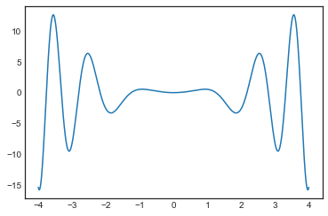

```python
import matplotlib.pyplot as plt
from matplotlib import style

style.use('seaborn-white')
X = np.linspace(-4, 4, 1000)
plt.plot(X, X**2*np.cos(X**2))
```

```python
print (plt.style.available)
```

```
['Solarize_Light2', '_classic_test_patch', 'bmh', 'classic', 'dark_background', 'fast', 'fivethirtyeight', 'ggplot', 'grayscale', 'seaborn', 'seaborn-bright', 'seaborn-colorblind', 'seaborn-dark', 'seaborn-dark-palette', 'seaborn-darkgrid', 'seaborn-deep', 'seaborn-muted', 'seaborn-notebook', 'seabo…
```

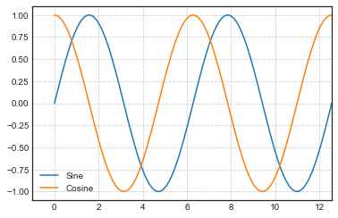

```python
#Multiple plots
xs = np.linspace(0, 4*np.pi, 100)  # 100 points in the interval [0 and 4*pi]
ys_sin = np.sin(xs)
ys_cos = np.cos(xs)

plt.figure()
plt.plot(xs, ys_sin, label='Sine')
plt.plot(xs, ys_cos, label='Cosine')
plt.xlim(-1, 4*np.pi)  # Limit what is displayed in the x direction
plt.legend()  # Requires that each curve has a label
plt.grid(linestyle='dashed')
plt.show()
```

# Python 3

- `print` is a function, so you **need** parentheses
- Division with `/` is always floating-point division
- Unicode differences

```python
# THE EXAMPLE BELOW IS PYTHON 2/3 COMPATIBLE

print("String with replacement: {}".format("Hello World"))
```

```
String with replacement: Hello World
```

# What if I don't like this notebook thing

Then, don't use it!

Recommended for exploration and for visualization, not so great for actual computing.

### Alternatives

1. A text editor (vim, emacs, nano...)
2. An IDE (spyder)
3. Ipython on the shell

# Documentation:

- Numpy docs: http://docs.scipy.org/doc/
- Matplotlib: http://matplotlib.org
- Python docs: http://docs.python.org

# Image reading and plotting

```python
from skimage.io import imsave, imread
```

```python
img=imread('Images/len_std.jpg')
```

[figure not shown]

```python
plt.imshow(img)
plt.axis('off')  # Turn off axis numbers and ticks
plt.show()
```

A simple colour image consists of three so-called colour channels: red, green, and blue. This means that image is in fact a three-dimensional array with the following shape:

```python
img.shape
```

```
(256, 256, 3)
```

The first and second axis are the rows and columns respectively, while the last axis is the number of channels. The channels can be operated on separately. The following exemplifies how each channel can be plotted on its own using subplot:

[figure not shown]

```python
r = img[..., 0]  # Equivalent to image[:, :, 0]
g = img[..., 1]
b = img[..., 2]

plt.figure(figsize=(10, 8))
plt.subplot(131)
plt.imshow(r, cmap=plt.cm.Reds)  # Red colour map
plt.axis('off')
plt.subplot(132)
plt.imshow(g, cmap=plt.cm.Greens)  # Green colour map
plt.axis('off')
plt.subplot(133)
plt.imshow(b, cmap=plt.cm.Blues)  # Blue colour map
plt.axis('off')

plt.tight_layout()
plt.show()
```